[figure not shown]

# UNDP Accelerator Labs Network Exploration and Visualization

### Question : Where are the solutions coming from? What is their distribution per country?

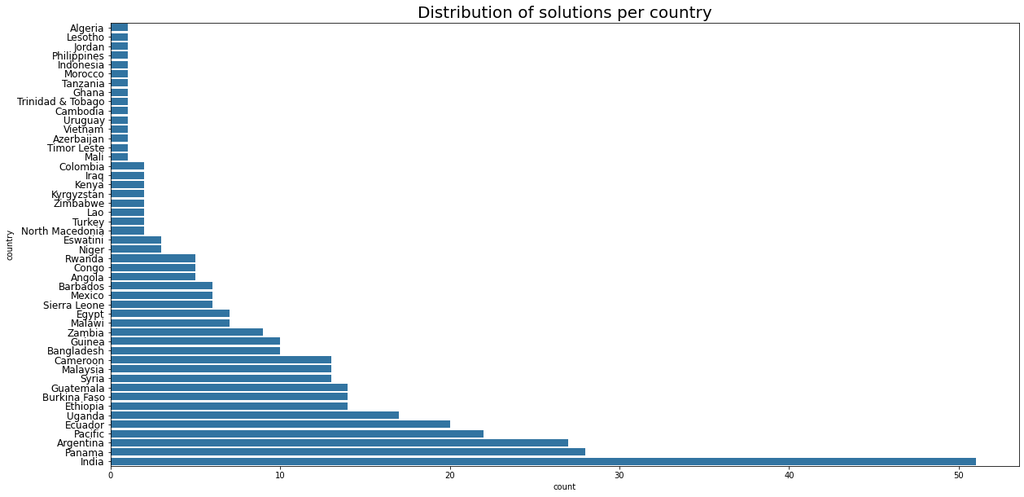

### Question : Where are the solutions coming from? What is their distribution per country?

- `India` has the highest number of solutions
- `Panama` is the second best solutions provider
- `Argentina` is the third best solutions provider
- `Pacific` is the fourth best solutions provider
- `Ecuador` is the fifth best solutions provider

### Question : Where are the solutions coming from? What is their distribution per region?

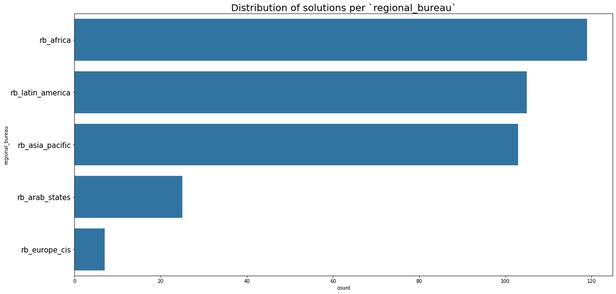

### Question : Where are the solutions coming from? What is their distribution per region?

- `rb_africa` has the highest number of solutions
- `rb_latin_america` is the second best solutions provider
- `rb_asia_pacific` is the third best solutions provider

### Question : What are global commonalities across solutions; what are typical applications & use cases for solutions? Are there patterns that emerge when looking at the distribution per country & per region?

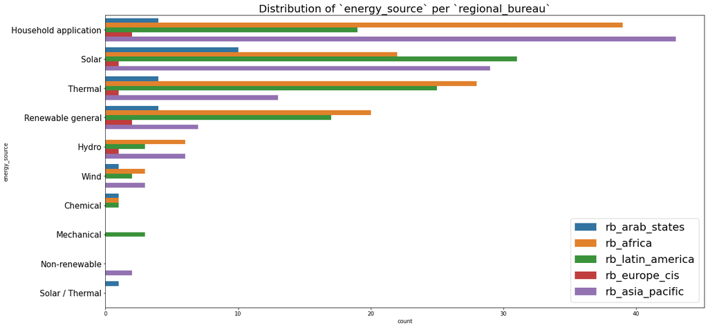

### Question : What are global commonalities across solutions; what are typical applications & use cases for solutions? Are there patterns that emerge when looking at the distribution per country & per region?

- The most produced `energy_source` is `Household application` and this solution is more prevalent in the regional bureau `rb_asia_pacific`, then `rb_africa` and `rb_latin_america`. It can be relative to the proverty level, which is high in these locations.
- The second most produced `energy_source` is `Solar` and more prevalent in the regional bureau `rb_latin_america` then `rb_asia_pacific`, `rb_africa` and `rb_arab_states`. It can be relative to the poor developpement of other energy sources in the locations of the first three, and the desert with his high level of solar reception in the locations of the `rb_arab_states`.
- The third most produced `energy_source` is `Thermal` and more prevalent in the regional bureau `rb_africa`, `rb_latin_america` and `rb_asia_pacific`.
- Overall energy sources, the more prevalent locations are `rb_africa`, `rb_latin_america` and `rb_asia_pacific`, certainly because of the development level which is low in these locations. That said, we understand why there are not so many solutions in `rb_europe_cis` and `rb_arab_states`.

### Question : What overall challenges are the solutions addressing or contributing to overcome?

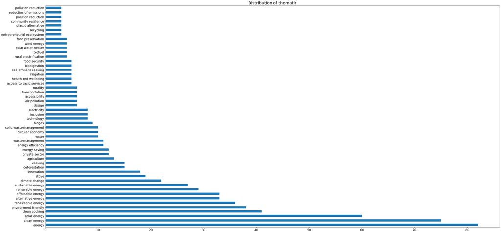

### Question : Which Sustainable Development Goals are the solutions advancing in particular, and how?

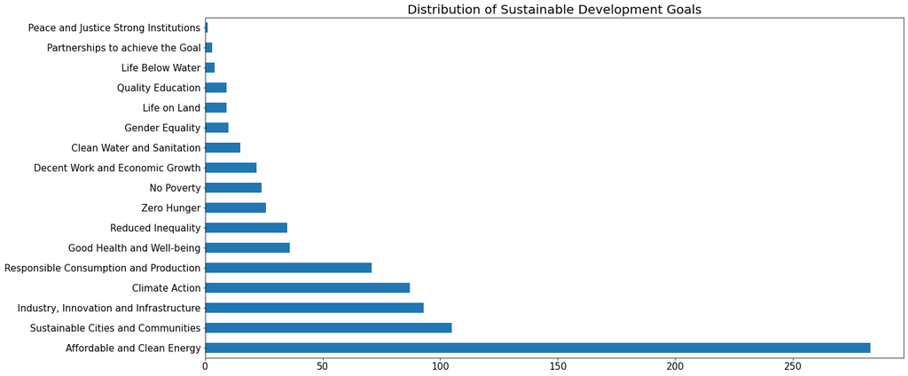

### Question : Which Sustainable Development Goals are the solutions advancing in particular, and how?

- The most represented SDG is `Affordable and Clean Energy`
- The second is `Sustainable Cities and Communities`
- The third is `Industry, Innovation and Infrastructure`

### Question : Looking at the use case of clean cooking solutions, what is their prevalence, distribution, and source of energy?

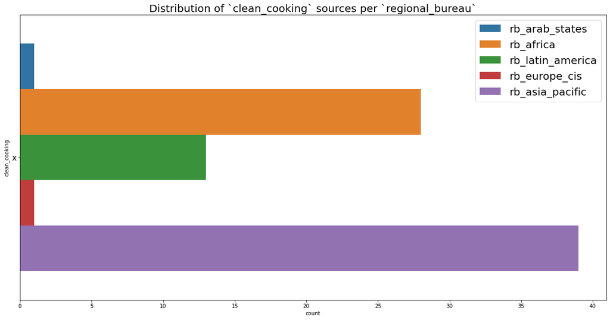

### Question : Looking at the use case of clean cooking solutions, what is their prevalence, distribution, and source of energy?

- More `clean_cooking` solutions are produced in `rb_asia_pacific`, `rb_africa` and `rb_latin_america`

### Question : Distribution of `sol_replication_training` sources per `regional_bureau`

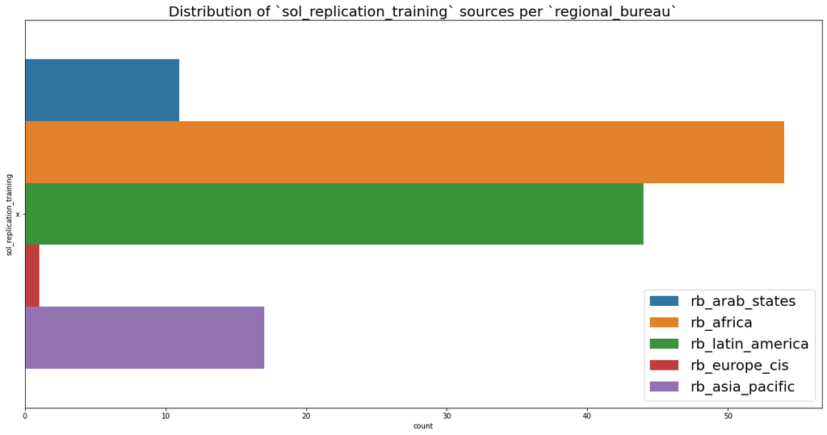

### Question : Distribution of `sol_replication_training` sources per `regional_bureau`

- Many solutions are replicable elsewhere, and most of solutions are coming from `rb_africa` and `rb_latin_america`.

### Question : Distribution of `product_availability` solutions per `regional_bureau`

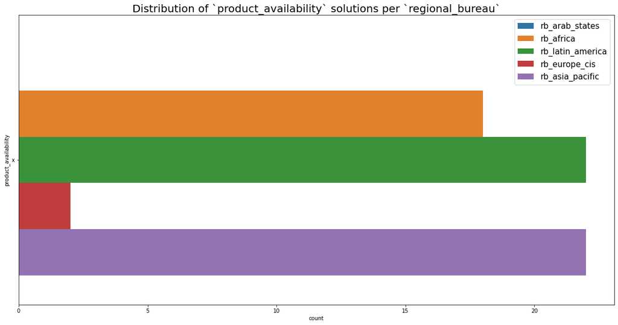

### Question : Distribution of `product_availability` solutions per `regional_bureau`

- Many solutions are products already available and waiting for scaling in the `rb_africa`, `rb_asia_pacific` and `rb_latin_america`.

### Question : Distribution of `product_advance_order` solutions per `regional_bureau`

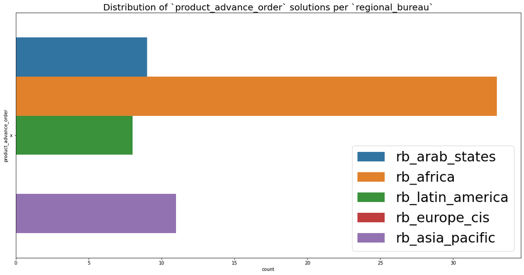

### Question : Distribution of `product_advance_order` solutions per `regional_bureau`

- Many solutions have been already ordered, most from `rb_africa`.

### Question : Distribution and repartition of each `sol_protection` (`Intellectual_property` or `open_source`)

[figure not shown]

### Question : Distribution and repartition of each `sol_protection` (`Intellectual_property` or `open_source`)

- Most of the solutions are `open_source` representing about `71.4%` overall.

### Question : Distribution of `sol_protection` (`Intellectual_property` or `open_source`) per `regional_bureau`

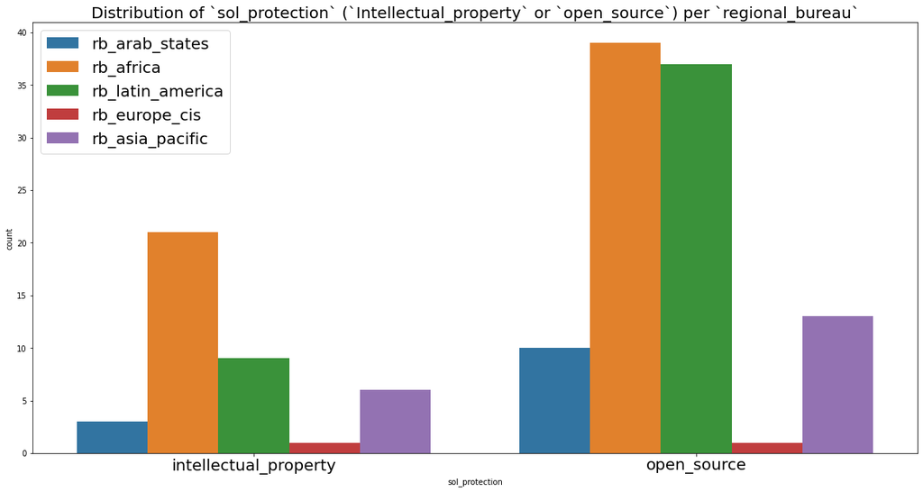

### Question : Distribution of `sol_protection` (`Intellectual_property` or `open_source`) per `regional_bureau`

- Most `open_source` solutions are from `rb_africa` and `rb_latin_america`.

### Question : Distribution of `sol_protection` (`Intellectual_property` or `open_source`) per `country`

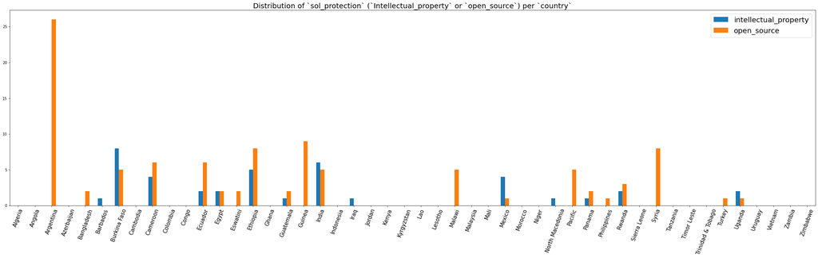

### Question : Distribution of `sol_protection` (`Intellectual_property` or `open_source`) per `country`

- Many coutries have more `open_source` solutions than `intellectual_property` solutions, such as `Argentina`, `Guinea`, `Cameroon`, `Ethiopia` and `Syria`.

### Question : Distribution and repartition of each `sol_type` (`prototype` or `product`)

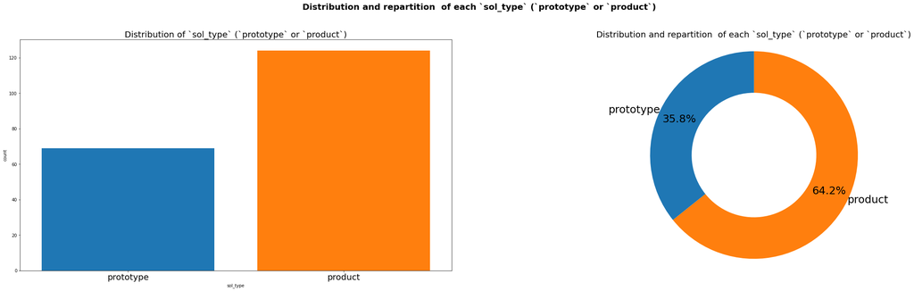

### Question : Distribution and repartition of each `sol_type` (`prototype` or `product`)

- Most of the solutions are `product` (ready to scale) representing about `64.2%` overall.

### Question : Distribution of `sol_type` (`prototype` or `product`) per `regional_bureau`

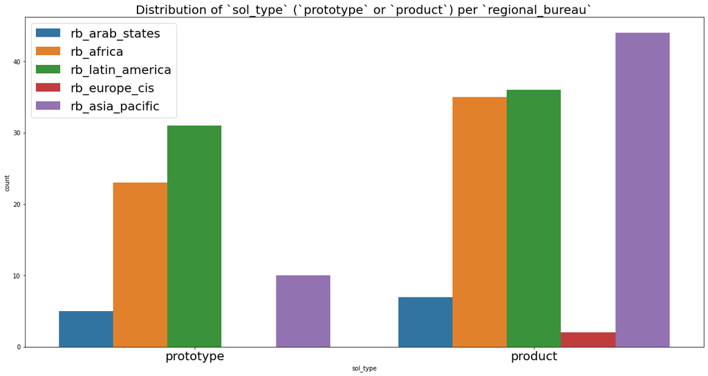

### Question : Distribution of `sol_type` (`prototype` or `product`) per `regional_bureau`

- Most `product` solutions are from `rb_africa`, `rb_asia_pacific` and `rb_latin_america`.

### Question : Distribution of `sol_type` (`prototype` or `product`) per `country`

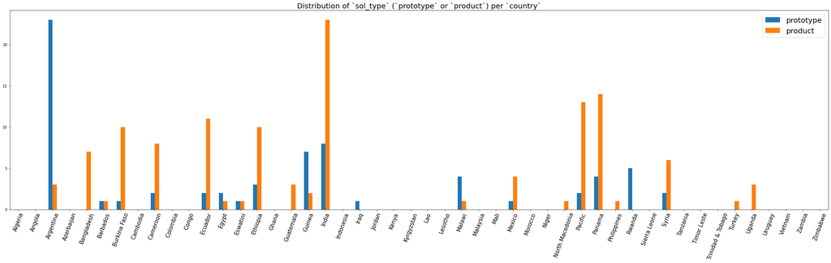

### Question : Distribution of `sol_type` (`prototype` or `product`) per `country`

- Many coutries have more `product` solutions (ready to scale) than `prototype` solutions, such as `India`, `Cameroon`, `Pacific`, `Panama`, `Ecuador`, `Burkina Faso` and `Ethiopia`.

### Question : Distribution of `sol_type` (`prototype` or `product`) per `trl_level`

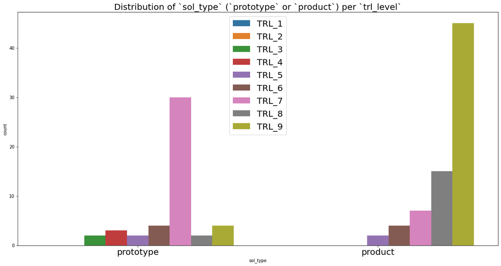

### Question : Distribution of `sol_type` (`prototype` or `product`) per `trl_level`

- Many product solutions have a TRL of 9 : Actual system proven in operational. They are ready to be scaled
- Many prototype solutions have a TRL of 7 : System prototype demonstration in operational environment.

### Question : Distribution of `sol_type` (`prototype` or `product`) per `sol_protection` (`Intellectual_property` or `open_source`) per `regional_bureau`

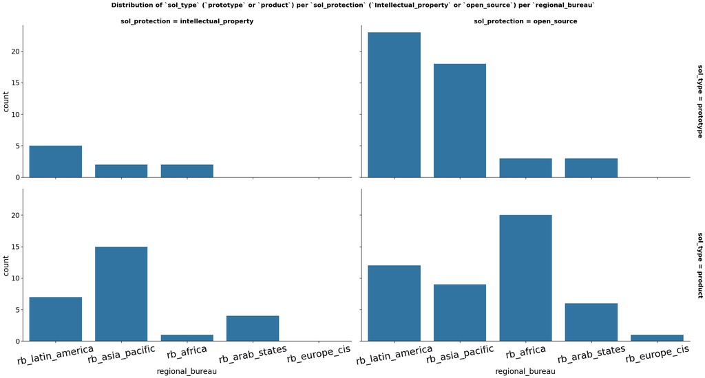

### Question : Distribution of `sol_type` (`prototype` or `product`) per `sol_protection` (`Intellectual_property` or `open_source`) per `regional_bureau`

- `rb_latin_america` has more `prototype` `open_source` solutions than `product` `open_source` solutions.
- `rb_asia_pacific` has more `prototype` `open_source` solutions than `product` `open_source` solutions.
- `rb_africa` has more `product` `open_source` solutions than `prototype` `open_source` solutions.

### Question : Distribution of `sol_type` (`prototype` or `product`) per `sol_protection` (`Intellectual_property` or `open_source`) per `country`

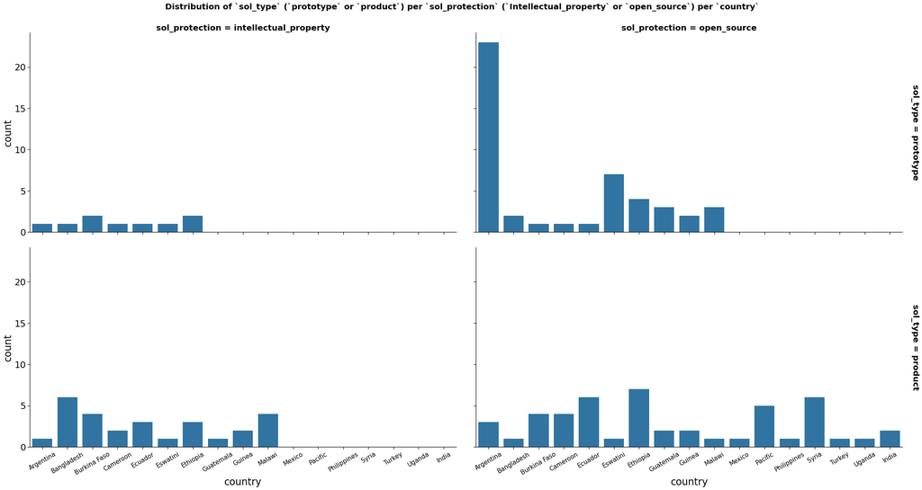

### Question : Distribution of `sol_type` (`prototype` or `product`) per `sol_protection` (`Intellectual_property` or `open_source`) per `country`

- Countries with more `prototype` `open_source` solutions than `product` `open_source` solutions: `Argentina`, `Eswatini`.
- Countries with more `product` `open_source` solutions than `prototype` `open_source` solutions: `Cameroon`, `Ecuador`, `Ethiopia`, `Burkina Faso`, `Pacific` and `Syria`.

### Question : Distribution of `sol_cost_usd` in Dollar US

```
<class 'pandas.core.series.Series'>
RangeIndex: 359 entries, 0 to 358
Series name: sol_cost_usd
Non-Null Count  Dtype
--------------  -----
59 non-null     float64
dtypes: float64(1)
memory usage: 2.9 KB
```

There are `59` solutions with exact production cost. Let's show it.

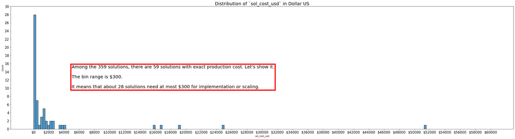

### Question : Distribution of `sol_cost_usd` in Dollar US

Among the 359 solutions, there are 59 solutions with exact production cost.

The bin range is $300.

## Conclusions

## Conclusions 1/5

- `India` has the highest number of solutions
- `Panama` is the second best solutions provider
- `Argentina` is the third best solutions provider
- `Pacific` is the fourth best solutions provider
- `Ecuador` is the fifth best solutions provider
- `rb_africa` has the highest number of solutions
- `rb_latin_america` is the second best solutions provider
- `rb_asia_pacific` is the third best solutions provider
- The most produced `energy_source` is `Household application` and this solution is more prevalent in the regional bureau `rb_asia_pacific`, then `rb_africa` and `rb_latin_america`. It can be relative to the proverty level, which is high in these locations.

## Conclusions 2/5

- The second most produced `energy_source` is `Solar` and more prevalent in the regional bureau `rb_latin_america` then `rb_asia_pacific`, `rb_africa` and `rb_arab_states`. It can be relative to the poor developpement of other energy sources in the locations of the first three, and the desert with his high level of solar reception in the locations of the `rb_arab_states`.
- The third most produced `energy_source` is `Thermal` and more prevalent in the regional bureau `rb_africa`, `rb_latin_america` and `rb_asia_pacific`.
- Overall energy sources, the more prevalent locations are `rb_africa`, `rb_latin_america` and `rb_asia_pacific`, certainly because of the development level which is low in these locations. That said, we understand why there are not so many solutions in `rb_europe_cis` and `rb_arab_states`.

## Conclusions 4/5

- Most of the solutions are `open_source` representing about `71.4%` overall.
- Most `open_source` solutions are from `rb_africa` and `rb_latin_america`.
- Most of the solutions are `product` (ready to scale) representing about `64.2%` overall.
- Most `product` solutions are from `rb_africa`, `rb_asia_pacific` and `rb_latin_america`.
- Many coutries have more `open_source` solutions than `intellectual_property` solutions, such as `Argentina`, `Guinea`, `Cameroon`, `Ethiopia` and `Syria`.
- Many coutries have more `product` solutions (ready to scale) than `prototype` solutions, such as `India`, `Cameroon`, `Pacific`, `Panama`, `Ecuador`, `Burkina Faso` and `Ethiopia`.
- Many product solutions have a TRL of 9 : Actual system proven in operational. They are ready to be scaled.
- Many prototype solutions have a TRL of 7 : System prototype demonstration in operational environment.

## Conclusions 5/5

- `rb_latin_america` has more `prototype` `open_source` solutions than `product` `open_source` solutions.
- `rb_asia_pacific` has more `prototype` `open_source` solutions than `product` `open_source` solutions.
- `rb_africa` has more `product` `open_source` solutions than `prototype` `open_source` solutions.
- Countries with more `prototype` `open_source` solutions than `product` `open_source` solutions: `Argentina`, `Eswatini`.
- Countries with more `product` `open_source` solutions than `prototype` `open_source` solutions: `Cameroon`, `Ecuador`, `Ethiopia`, `Burkina Faso`, `Pacific` and `Syria`.

Among the 359 solutions, there are 59 solutions with exact production cost.

The bin range is $300.

It means that about 28 solutions need at most $300 for implementation or scaling

## Feedback

Thank you for paying attention to our team work. Please we need your review to improve ourselves.

- What do you notice about each visualization?
- What questions do you have about the data?
- What relationships do you notice?
- What do you think is the main takeaway from the report / presentation?
- Is there anything that you don’t understand from the plots?

Kindly reach us:

- Jozias Tema
  - LinkedIn : [jozias-tema](https://www.linkedin.com/in/jozias-tema-496a1523a/)
  - GitHub : [jozias-tema](https://github.com/temajozias/)
  - Gmail : jozias-tema or temajozias@gmail.com
- Yvvon Jemmy
  - GitHub : [YvvonJemmy](https://github.com/YvvonJemmy/)
  - Gmail : YvvonJemmy yvvonjemymahmajala@gmail.com
- Angie Bil
  - GitHub : AngieBil
  - Gmail : AngieBil kbilhah@gmail.com